# Predictive Modeling of Student Academic Performance

Identifying At-Risk Students using Computational Intelligence

Olanrewaju Yusuf

2026-01-11

```r
# install packages
# install.packages(c("tidyverse", "caret", "corrplot", "gridExtra", "Rcpp", "tibble"), type = "binary")
# install.packages(c("parallelly", "future", "listenv", "globals"), type = "binary")
# install.packages("rpart.plot")

# import packages
library(tidyverse)  # For data manipulation and visualization (ggplot2)
library(caret)      # For Machine Learning workflow
library(corrplot)   # For correlation heatmaps
library(gridExtra)  # To arrange plots side-by-side
```

We will be using the Portuguese Language course data because it is a larger dataset. The math dataset is included in the ./data folder.

```r
student_data <- read.csv('./data/student-por.csv', sep = ';', stringsAsFactors = TRUE)
```

### 1 EDA - sanity check

```r
# Inspect head and bottom rows
head(student_data)
```

```
##   school sex age address famsize Pstatus Medu Fedu     Mjob     Fjob     reason
## 1     GP   F  18       U     GT3       A    4    4  at_home  teacher     course
## 2     GP   F  17       U     GT3       T    1    1  at_home    other     course
## 3     GP   F  15       U     LE3       T    1    1  at_home    other      other
## 4     GP   F  15       U     GT3       T    4    2   health services       home
## 5     GP   F  16       U     GT3       T    3    3    other    other       home
## 6     GP   M  16       U     LE3       T    4    3 services    other reputation
##   guardian traveltime studytime failures schoolsup famsup paid activities
## 1   mother          2         2        0       yes     no   no         no
## 2   father          1         2        0        no    yes   no         no
## 3   mother          1         2        0       yes     no   no         no
## 4   mother          1         3        0        no    yes   no        yes
## 5   father          1         2        0        no    yes   no         no
## 6   mother          1         2        0        no    yes   no        yes
##   nursery higher internet romantic famrel freetime goout Dalc Walc health
## 1     yes    yes       no       no      4        3     4    1    1      3
## 2      no    yes      yes       no      5        3     3    1    1      3
## 3     yes    yes      yes       no      4        3     2    2    3      3
## 4     yes    yes      yes      yes      3        2     2    1    1      5
## 5     yes    yes       no       no      4        3     2    1    2      5
## 6     yes    yes      yes       no      5        4     2    1    2      5
##   absences G1 G2 G3
## 1        4  0 11 11
## 2        2  9 11 11
## 3        6 12 13 12
## 4        0 14 14 14
## 5        0 11 13 13
## 6        6 12 12 13
```

```r
tail(student_data)
```

```
##     school sex age address famsize Pstatus Medu Fedu     Mjob     Fjob
## 644     MS   F  18       R     GT3       T    4    4  teacher  at_home
## 645     MS   F  19       R     GT3       T    2    3 services    other
## 646     MS   F  18       U     LE3       T    3    1  teacher services
## 647     MS   F  18       U     GT3       T    1    1    other    other
## 648     MS   M  17       U     LE3       T    3    1 services services
## 649     MS   M  18       R     LE3       T    3    2 services    other
##         reason guardian traveltime studytime failures schoolsup famsup paid
## 644 reputation   mother          3         1        0        no    yes   no
## 645     course   mother          1         3        1        no     no   no
## 646     course   mother          1         2        0        no    yes   no
## 647     course   mother          2         2        0        no     no   no
## 648     course   mother          2         1        0        no     no   no
## 649     course   mother          3         1        0        no     no   no
##     activities nursery higher internet romantic famrel freetime goout Dalc Walc
## 644        yes     yes    yes      yes      yes      4        4     3    2    2
## 645        yes      no    yes      yes       no      5        4     2    1    2
## 646         no     yes    yes      yes       no      4        3     4    1    1
## 647        yes     yes    yes       no       no      1        1     1    1    1
## 648         no      no    yes      yes       no      2        4     5    3    4
## 649         no      no    yes      yes       no      4        4     1    3    4
##     health absences G1 G2 G3
## 644      5        4  7  9 10
## 645      5        4 10 11 10
## 646      1        4 15 15 16
## 647      5        6 11 12  9
## 648      2        6 10 10 10
## 649      5        4 10 11 11
```

Check the dimensions and column names

```r
dim(student_data)
```

```
## [1] 649  33
```

```r
colnames(student_data)
```

```
##  [1] "school"     "sex"        "age"        "address"    "famsize"
##  [6] "Pstatus"    "Medu"       "Fedu"       "Mjob"       "Fjob"
## [11] "reason"     "guardian"   "traveltime" "studytime"  "failures"
## [16] "schoolsup"  "famsup"     "paid"       "activities" "nursery"
## [21] "higher"     "internet"   "romantic"   "famrel"     "freetime"
## [26] "goout"      "Dalc"       "Walc"       "health"     "absences"
## [31] "G1"         "G2"         "G3"
```

We can confirm the dataset is complete as stated in the source. We can make meaning of the features by looking at ./data/student.txt.

The dataset does not contain any missing value so we don’t have to perform imputation step

```r
# structure of data
str(student_data)
```

```
## 'data.frame':    649 obs. of  33 variables:
##  $ school    : Factor w/ 2 levels "GP","MS": 1 1 1 1 1 1 1 1 1 1 ...
##  $ sex       : Factor w/ 2 levels "F","M": 1 1 1 1 1 2 2 1 2 2 ...
##  $ age       : int  18 17 15 15 16 16 16 17 15 15 ...
##  $ address   : Factor w/ 2 levels "R","U": 2 2 2 2 2 2 2 2 2 2 ...
##  $ famsize   : Factor w/ 2 levels "GT3","LE3": 1 1 2 1 1 2 2 1 2 1 ...
##  $ Pstatus   : Factor w/ 2 levels "A","T": 1 2 2 2 2 2 2 1 1 2 ...
##  $ Medu      : int  4 1 1 4 3 4 2 4 3 3 ...
##  $ Fedu      : int  4 1 1 2 3 3 2 4 2 4 ...
##  $ Mjob      : Factor w/ 5 levels "at_home","health",..: 1 1 1 2 3 4 3 3 4 3 ...
##  $ Fjob      : Factor w/ 5 levels "at_home","health",..: 5 3 3 4 3 3 3 5 3 3 ...
##  $ reason    : Factor w/ 4 levels "course","home",..: 1 1 3 2 2 4 2 2 2 2 ...
##  $ guardian  : Factor w/ 3 levels "father","mother",..: 2 1 2 2 1 2 2 2 2 2 ...
##  $ traveltime: int  2 1 1 1 1 1 1 2 1 1 ...
##  $ studytime : int  2 2 2 3 2 2 2 2 2 2 ...
```

[output cut: 19 more lines]

```r
# check for missing value
sum(is.na(student_data))
```

```
## [1] 0
```

#### 1.1 Observations:

- The dataset contains 649 observations and 33 variables.
- There are no missing values (NA), so no imputation is required.
- Variables like Medu, Fedu, traveltime, studytime are currently Integers but represent ordinal categories.
- The target variable G3 (Final Grade) is numeric (0-20).

### 2 Feature Engineering

```r
# We need to combine mother and father education into a "Parent Education" metric
# Medu and Fedu range from 0 (none) to 4 (higher education)
student_data$Parent_Edu_Total <- student_data$Medu + student_data$Fedu

# Create a binary target for classification (Pass/Fail)
# If G3 < 10, the student is "At Risk" (Fail), otherwise, "Safe" (Pass)
student_data$is_AtRisk <- ifelse(student_data$G3 < 10, "Yes", "No")
student_data$is_AtRisk <- as.factor(student_data$is_AtRisk)

# convert ordinal integers to factors for better visualization
# we keep the original numeric versions for regression, but create factor versions for ploting
student_data$studytime_factor <- as.factor(student_data$studytime)
student_data$famrel_factor <- as.factor(student_data$famrel)
student_data$traveltime_factor <- as.factor(student_data$traveltime)

# verify the new columns
summary(student_data$Parent_Edu_Total)
```

```
##    Min. 1st Qu.  Median    Mean 3rd Qu.    Max.
##   0.000   3.000   5.000   4.821   6.000   8.000
```

```r
table(student_data$is_AtRisk)
```

```
##
##  No Yes
## 549 100
```

#### 2.1 Observations:

- Parent_Edu_Total ranges from 0-8. A higher score indicates a highly educated household
- is_AtRisk devides students into 2 clases (as intended). Students who passed (>=10), and those at risk (<10)

### 3 Pattern Detection (EDA)

we want to investigate Attendance (Absences) and Study Time to address the project’s core hypothesis regarding behavioral factors

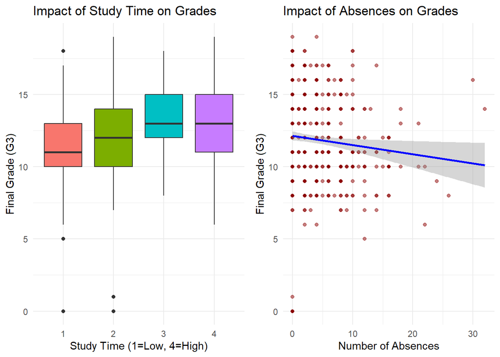

```r
# Pattern 1: Study Time vs. Final Grade (G3)
p1 <- ggplot(student_data, aes(x=studytime_factor, y=G3, fill=studytime_factor)) + geom_boxplot() + labs(title="Impact of Study Time on Grades", x="Study Time (1=Low, 4=High)", y="Final Grade (G3)") + theme_minimal() + theme(legend.position="none")

# Pattern 2: Absences vs. Final Grade (G3)
# Using a scatter plot with a smoothing line to detect trends
p2 <- ggplot(student_data, aes(x=absences, y=G3)) + geom_point(alpha=0.5, color="darkred") + geom_smooth(method="lm", color="blue") + labs(title="Impact of Absences on Grades", x="Number of Absences", y="Final Grade (G3)") + theme_minimal()

grid.arrange(p1, p2, ncol=2)
```

#### 3.1 EDA Observations:

- Study Time: There is a visible positive trend; students with higher study time categories (3 or 4) generally achieve higher median grades compared to those in category 1.
- Absences: The scatter plot indicates a slight negative correlation. As absences increase, the final grade tends to drop, identifying attendance as a potential risk factor.

### 4 Statistical Hypothesis Testing

We need to prove that our features maters statistically

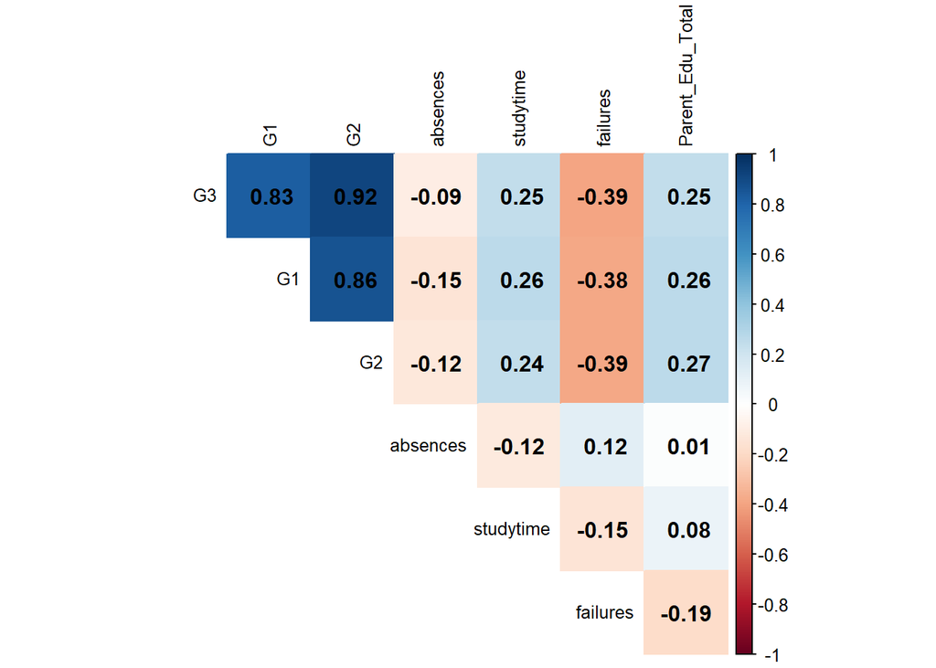

```r
# 1. Correlation Matrix (Numeric Variables)
# We select only numeric columns to see what correlates with G3
numeric_vars <- student_data %>% select(G3, G1, G2, absences, studytime, failures, Parent_Edu_Total)
cor_matrix <- cor(numeric_vars)

# Plotting the Heatmap
corrplot(cor_matrix, method = "color", type = "upper",
         tl.col = "black", tl.cex = 0.8, addCoef.col = "black", diag = FALSE)
```

```r
# 2. Chi-Square Test (Categorical Variables)
# Testing if 'Desire for Higher Education' affects 'At Risk' status
# H0: They are independent (No relationship)
# H1: They are dependent (Relationship exists)
chisq_test_higher <- chisq.test(table(student_data$higher, student_data$is_AtRisk))
print(chisq_test_higher)
```

```
##
##  Pearson's Chi-squared test with Yates' continuity correction
##
## data:  table(student_data$higher, student_data$is_AtRisk)
## X-squared = 59.499, df = 1, p-value = 1.223e-14
```

```r
# Testing if 'Internet Access' affects 'At Risk' status
chisq_test_net <- chisq.test(table(student_data$internet, student_data$is_AtRisk))
print(chisq_test_net)
```

```
##
##  Pearson's Chi-squared test with Yates' continuity correction
##
## data:  table(student_data$internet, student_data$is_AtRisk)
## X-squared = 4.4887, df = 1, p-value = 0.03412
```

#### 4.1 Observations:

- Correlation: The heatmap confirms that prior grades (G1, G2) have the strongest correlation with G3 (r > 0.80). We also observed that, ‘failures’ has a significant negative correlation, this means that, past failures are a strong predictor of future poor performance.
- Chi-Square Tests: The p-value for ‘higher’ (desire for higher education) is extremely low (p < 0.05), allowing us to reject the Null Hypothesis. This proves that a student’s motivation for higher education is statistically linked to their risk of failure.

### 5 Data Partition and Regression Modelling

we split the data and build a Regression model to predict the exact grade

```r
# Data partitioning
set.seed(123) # to ensure reproducibility

# split data -> 70% Training, 30% Testing
# We use createDataPartition from 'caret' which preserves the distribution of G3
trainIndex <- createDataPartition(student_data$G3, p = .7, list = FALSE, times = 1)
train_set <- student_data[trainIndex,]
test_set  <- student_data[-trainIndex,]

# Check dimensions
dim(train_set)
```

```
## [1] 456  38
```

```r
dim(test_set)
```

```
## [1] 193  38
```

```r
# Model 1: Linear Regression (Predicting Exact Grade)
# We remove 'is_AtRisk' (target for classification) and 'G3' (target for regression) from predictors

# Train the model
model_lm <- lm(G3 ~ G1 + G2 + studytime + failures + absences + Parent_Edu_Total + higher + internet,
               data = train_set)

# View Model Summary (Coefficients and R-squared)
summary(model_lm)
```

```
##
## Call:
## lm(formula = G3 ~ G1 + G2 + studytime + failures + absences +
##     Parent_Edu_Total + higher + internet, data = train_set)
##
## Residuals:
##     Min      1Q  Median      3Q     Max
## -7.3460 -0.4908 -0.0775  0.5857  2.6236
##
## Coefficients:
##                  Estimate Std. Error t value Pr(>|t|)
## (Intercept)      -0.33028    0.29508  -1.119   0.2636
## G1                0.15216    0.03701   4.111 4.68e-05 ***
## G2                0.87776    0.03407  25.762  < 2e-16 ***
## studytime         0.12332    0.06443   1.914   0.0562 .
## failures         -0.20842    0.10100  -2.064   0.0396 *
## absences          0.02258    0.01157   1.952   0.0516 .
## Parent_Edu_Total -0.01638    0.02695  -0.608   0.5436
## higheryes         0.01125    0.19062   0.059   0.9530
## internetyes       0.18512    0.12694   1.458   0.1455
## ---
## Signif. codes:  0 '***' 0.001 '**' 0.01 '*' 0.05 '.' 0.1 ' ' 1
##
## Residual standard error: 1.106 on 447 degrees of freedom
## Multiple R-squared:  0.8851, Adjusted R-squared:  0.883
## F-statistic: 430.4 on 8 and 447 DF,  p-value: < 2.2e-16
```

```r
# Make Predictions on Test Set
predictions_lm <- predict(model_lm, test_set)

# Evaluate Performance (RMSE and R-squared)
postResample(pred = predictions_lm, obs = test_set$G3)
```

```
##      RMSE  Rsquared       MAE
## 1.5505834 0.7684197 0.8905616
```

#### 5.1 Observations:

- The model achieved an Adjusted R-squared of 0.883, indicating that our predictors successfullt explain 88.3% of the varience in student grades.
- The Root Mean Square Error (RSME) on test set was 1.55 points of the students’ actual final score
- Key Drivers:
  - The strongest predictor was the second period grade (G2), with a highly significant p-value ($p < 0.001$). The coefficient of 0.87 indicates that performance in the second term is nearly a direct proxy for final performance.
  - History of failure (failures) was statistically significant ($p = 0.039$) and negatively correlated. Even when controlling for current grades, past failures exert a lingering negative impact on outcomes.
  - Interestingly, socio-economic variables like Parent Education and Internet Access were not statistically significant in this model ($p > 0.05$). This implies that while these factors might influence initial performance, they are overshadowed by recent academic results (G1 and G2) when predicting the final grade.

### 6 Classification Model and Visualization

We will intentionally exclude G1 and G2 from the predictors. If we leave them, the tree will say “If G2 < 10, then Fail.”. By removing them, we force the model to find the behavioral root causes (like study time, alcohol, family support) that lead to failure.

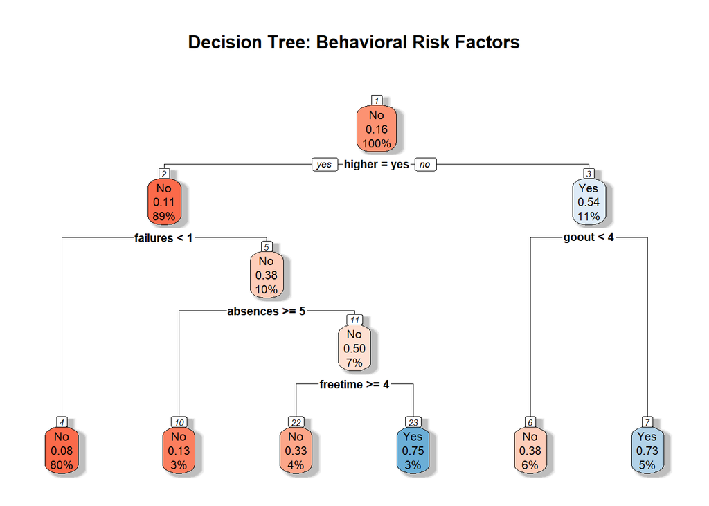

```r
# Train Decision Tree Model
library(rpart)
library(rpart.plot)

# We include a mix of social, demographic, and behavioral features
tree_model <- rpart(is_AtRisk ~ studytime + failures + absences + Parent_Edu_Total +higher + internet + freetime + goout + Walc + Dalc, data = train_set, method = "class", control = rpart.control(cp = 0.015)) # cp controls tree complexity

# Visualize the Decision Tree
rpart.plot(tree_model, box.palette = "RdBu", shadow.col = "gray", nn = TRUE, main = "Decision Tree: Behavioral Risk Factors")
```

```r
# Evaluate the Classifier
tree_pred <- predict(tree_model, test_set, type = "class")

# Confusion Matrix (Accuracy, Precision, Recall)
# This tells us how good the model is at catching failing students
conf_matrix <- confusionMatrix(tree_pred, test_set$is_AtRisk, positive = "Yes")
print(conf_matrix)
```

```
## Confusion Matrix and Statistics
##
##           Reference
## Prediction  No Yes
##        No  155  21
##        Yes   9   8
##
##                Accuracy : 0.8446
##                  95% CI : (0.7856, 0.8926)
##     No Information Rate : 0.8497
##     P-Value [Acc > NIR] : 0.62679
##
##                   Kappa : 0.2663
##
##  Mcnemar's Test P-Value : 0.04461
##
##             Sensitivity : 0.27586
##             Specificity : 0.94512
##          Pos Pred Value : 0.47059
##          Neg Pred Value : 0.88068
##              Prevalence : 0.15026
##          Detection Rate : 0.04145
##    Detection Prevalence : 0.08808
##       Balanced Accuracy : 0.61049
##
##        'Positive' Class : Yes
##
```

### 8 Conclusion

#### 8.1 Recommendation:

Based on these findings, the recommendation to educational institutions is to implement a two-leveled early warning system: